# Analysis

Elodie Kwan and Katia Voltz

2022-04-26

## Methodology

In this section we will talk about the methodology that has been used and the different models analysis that has been conducted.

### Traning set and Test set

First of all we started by splitting our dataset into 2 sets: **training set** (`German_credit.tr`) and **test set** (`German_credit.te`). We do not forget to take the first variable **OBS.** out as it represents the index number for each observation. These two sets will allow us to train some models on the **training set** and then test the accuracy of the model fit on the **test set**.

### Balancing the dataset

Then, we applied the balancing data technique in order to improve the predictions of **Good Credit** and **Bad Credit**, since we have more observations on the **Good Credit**.

Indeed, we observe that the “Good Credit” (1) response appears **527** times in the training set and “Bad Credit” (0) **223**, two times less. Since there are many more “Good Credit” than “Bad Credit”, any model favors the prediction of the “Good Credit”. It results a good accuracy but the specificity is low, as well as the balanced accuracy.

#### Sub-sampling

Balancing using sub-sampling consists of taking all the cases in the smallest class (here “Bad Credit”) and extract at random the same amount of cases in the largest category (here “Good”).

The **training set** is now balanced, we have 223 observations for both “Good Credit” (1) and “Bad Credit” (0). The new balanced training set is called `German_Credit.tr.subs`.

### Models Fitting

Once we had our training set and test set, we could fit some models and compare them with together to choose the best model.

#### 1. Classification Tree (Decision Tree)

We first started with a decision tree and more specifically we chose the classification tree as we want to classify the applicants. The model was build on our previously balanced training set `German_Credit.tr.subs`. We used the R function `rpart`.

We obtained the following large tree.

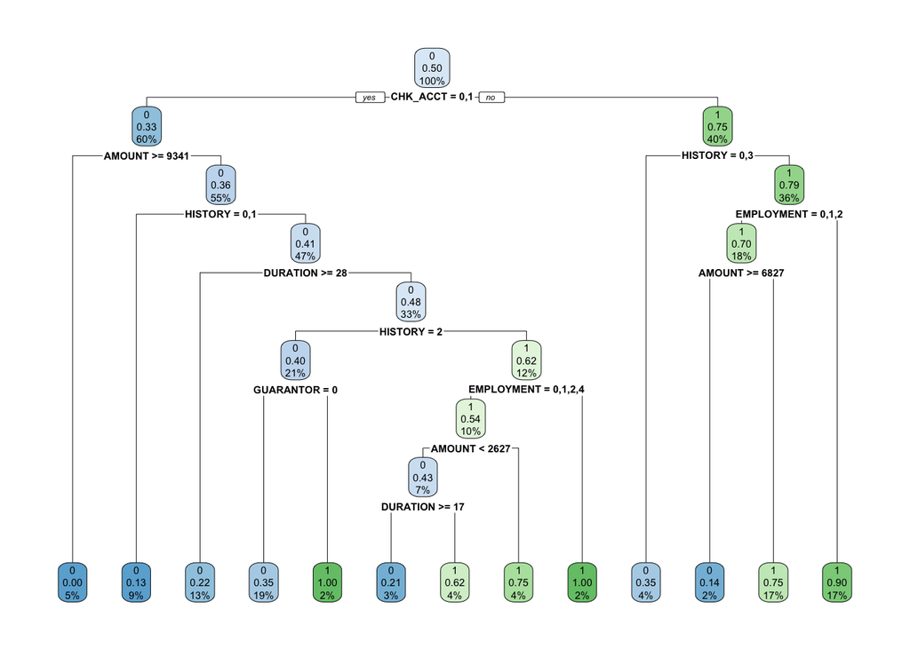

Confusion Matrix of the Big classification tree

|  | Bad credit risk | Good credit risk |
| --- | --- | --- |
| **Bad credit risk** | 58 | 70 |
| **Good credit risk** | 19 | 103 |

```
##          Sensitivity          Specificity       Pos Pred Value
##            0.7532468            0.5953757            0.4531250
##       Neg Pred Value            Precision               Recall
##            0.8442623            0.4531250            0.7532468
##                   F1           Prevalence       Detection Rate
##            0.5658537            0.3080000            0.2320000
## Detection Prevalence    Balanced Accuracy
##            0.5120000            0.6743112
```

As the tree is quite big and we want to know if we can prune it. To do so, we decided to use the `printcp` and `plotcp` commands and choose the best **cp** (complexity parameter) value to prune our tree.

##### Pruning the tree

```
##
## Classification tree:
## rpart(formula = RESPONSE ~ ., data = German_Credit.tr.subs, method = "class")
##
## Variables actually used in tree construction:
## [1] AMOUNT     CHK_ACCT   DURATION   EMPLOYMENT GUARANTOR  HISTORY
##
## Root node error: 223/446 = 0.5
##
## n= 446
##
##         CP nsplit rel error  xerror     xstd
## 1 0.399103      0   1.00000 1.08520 0.047179
## 2 0.022422      1   0.60090 0.63677 0.044117
## 3 0.014574      2   0.57848 0.66816 0.044668
## 4 0.011958      7   0.48430 0.69058 0.045028
## 5 0.011211     10   0.44843 0.67265 0.044742
## 6 0.010000     12   0.42601 0.67265 0.044742
```

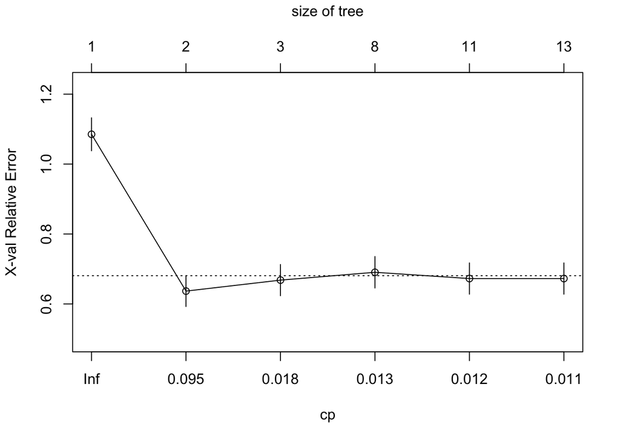

From the list of **cp** (complexity parameter), we would choose the line that has the lowest cross validation error. This can be seen on the column **xerror**. So the best cp would be 0.022422 with one split.

The value of cp can be chosen arbitrarily between 0.018 and 0.095. So we decided to go with the suggested cp of 0.022 from the summary.

With these value, we obtain a very small tree.

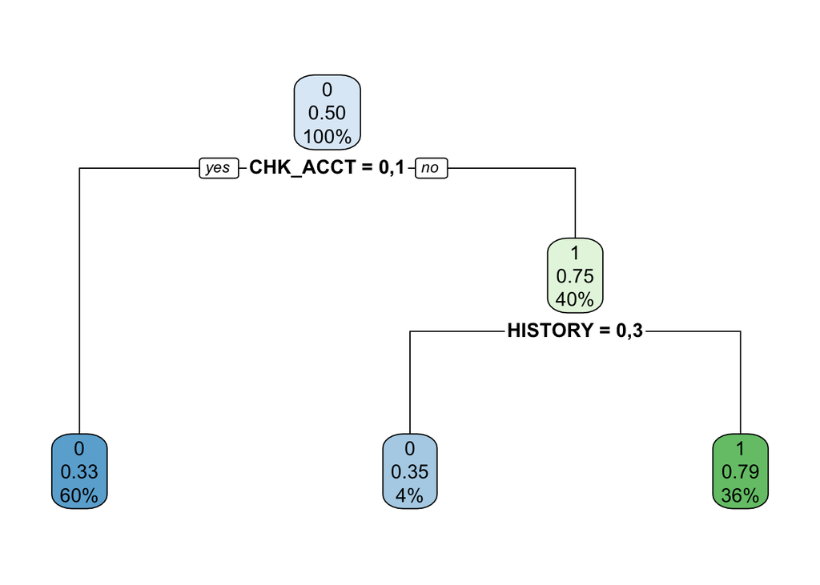

This pruned decision tree with a cp of 0.022 uses the variables **CHK_ACCT** and **HISTORY**.

Using this pruned tree, we can computed the prediction and build a confusion matrix to see the performance of the model.

Confusion Matrix of the Pruned classification tree

|  | Bad credit risk | Good credit risk |
| --- | --- | --- |
| **Bad credit risk** | 63 | 95 |
| **Good credit risk** | 14 | 78 |

```
##          Sensitivity          Specificity       Pos Pred Value
##            0.8181818            0.4508671            0.3987342
##       Neg Pred Value            Precision               Recall
##            0.8478261            0.3987342            0.8181818
##                   F1           Prevalence       Detection Rate
##            0.5361702            0.3080000            0.2520000
## Detection Prevalence    Balanced Accuracy
##            0.6320000            0.6345244
```

We also decided to look at what would an automatically pruned using 1-SE rule would give us and whether or not it is better than the pruned tree we made by looking at the cp.

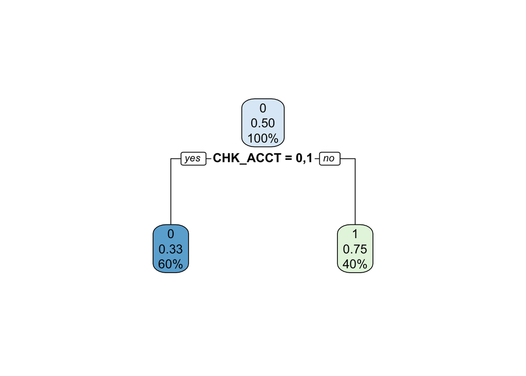

Here, only the variable **CHK_ACCT** is used. As we prune the tree more information are lost.

Confusion Matrix of the Autoruned classification tree

|  | Bad credit risk | Good credit risk |
| --- | --- | --- |
| **Bad credit risk** | 61 | 88 |
| **Good credit risk** | 16 | 85 |

```
##          Sensitivity          Specificity       Pos Pred Value
##            0.7922078            0.4913295            0.4093960
##       Neg Pred Value            Precision               Recall
##            0.8415842            0.4093960            0.7922078
##                   F1           Prevalence       Detection Rate
##            0.5398230            0.3080000            0.2440000
## Detection Prevalence    Balanced Accuracy
##            0.5960000            0.6417686
```

##### Variable importance of the classification tree

```
##                    Overall
## AMOUNT           17.947179
## CHK_ACCT         37.098755
## DURATION         11.073258
## EMPLOYMENT        4.645266
## HISTORY          18.840050
## OTHER_INSTALL     3.216630
## RETRAINING        3.509915
## SAV_ACCT          9.538067
## NEW_CAR           0.000000
## USED_CAR          0.000000
## FURNITURE         0.000000
## RADIO.TV          0.000000
## EDUCATION         0.000000
## INSTALL_RATE      0.000000
## MALE_DIV          0.000000
## MALE_SINGLE       0.000000
## MALE_MAR_or_WID   0.000000
## CO.APPLICANT      0.000000
## GUARANTOR         0.000000
## PRESENT_RESIDENT  0.000000
## REAL_ESTATE       0.000000
## PROP_UNKN_NONE    0.000000
## AGE               0.000000
## RENT              0.000000
## OWN_RES           0.000000
## NUM_CREDITS       0.000000
## JOB               0.000000
## NUM_DEPENDENTS    0.000000
## TELEPHONE         0.000000
## FOREIGN           0.000000
```

[figure not shown]

From this plot, we see that the variables that influences the most are **CHK_ACCT**, **HISTORY**, **SAV_ACCT**, **DURATION**, **AMOUNT** and **REAL_ESTATE**. They are not exactly the same as the one we saw above.

The variable **CHK_ACCT** and **HISTORY** were noticed though.

#### 2. Logistic Regression

The next model we performed is a logistic regression.

```
##
## Call:
## glm(formula = RESPONSE ~ ., family = binomial, data = German_Credit.tr.subs)
##
## Deviance Residuals:
##      Min        1Q    Median        3Q       Max
## -2.34578  -0.68043   0.00049   0.65178   2.74937
##
## Coefficients:
##                     Estimate Std. Error z value Pr(>|z|)
## (Intercept)        1.1911402  1.7958756   0.663 0.507161
## CHK_ACCT1          0.5692882  0.3363406   1.693 0.090533 .
## CHK_ACCT2          0.8404451  0.5339512   1.574 0.115485
## CHK_ACCT3          2.4337691  0.3770606   6.455 1.09e-10 ***
## DURATION          -0.0123731  0.0142153  -0.870 0.384078
## HISTORY1          -1.0734853  0.8514386  -1.261 0.207384
## HISTORY2           0.0865599  0.6747882   0.128 0.897930
## HISTORY3          -0.0598560  0.7410028  -0.081 0.935619
## HISTORY4           1.1072483  0.6576414   1.684 0.092246 .
## NEW_CAR1          -0.4538649  0.5853211  -0.775 0.438096
## USED_CAR1          1.6322817  0.7540134   2.165 0.030404 *
## FURNITURE1         0.0509645  0.6182782   0.082 0.934305
## RADIO.TV1          0.5261147  0.5896893   0.892 0.372291
## EDUCATION1         0.5441469  0.7499724   0.726 0.468111
## RETRAINING1       -0.4293160  0.6787931  -0.632 0.527080
## AMOUNT            -0.0002155  0.0000739  -2.916 0.003550 **
## SAV_ACCT1          0.6181742  0.4475399   1.381 0.167195
## SAV_ACCT2         -0.2531524  0.5541205  -0.457 0.647776
## SAV_ACCT3          0.7292579  0.6813687   1.070 0.284492
## SAV_ACCT4          1.4221687  0.4243610   3.351 0.000804 ***
## EMPLOYMENT1        0.7574673  0.7956778   0.952 0.341108
## EMPLOYMENT2        1.4785839  0.7640267   1.935 0.052959 .
## EMPLOYMENT3        1.9691166  0.7947873   2.478 0.013229 *
## EMPLOYMENT4        1.8560330  0.7511387   2.471 0.013475 *
## INSTALL_RATE      -0.3367533  0.1411404  -2.386 0.017035 *
## MALE_DIV1         -0.5653453  0.5705857  -0.991 0.321775
## MALE_SINGLE1       0.1618525  0.3327207   0.486 0.626647
## MALE_MAR_or_WID1  -0.5551862  0.5312986  -1.045 0.296041
## CO.APPLICANT1     -0.6994379  0.6920599  -1.011 0.312179
## GUARANTOR1         1.7126786  0.6556150   2.612 0.008993 **
```

[output cut: 11 more lines]

```
## JOB2              -1.2142377  1.1317833  -1.073 0.283337
## JOB3              -1.4358446  1.1604352  -1.237 0.215964
## NUM_DEPENDENTS     0.1270172  0.3832474   0.331 0.740325
## TELEPHONE1         0.6259633  0.3143236   1.991 0.046430 *
## FOREIGN1           1.2496315  0.8543880   1.463 0.143576
## ---
## Signif. codes:  0 '***' 0.001 '**' 0.01 '*' 0.05 '.' 0.1 ' ' 1
##
## (Dispersion parameter for binomial family taken to be 1)
##
##     Null deviance: 618.29  on 445  degrees of freedom
## Residual deviance: 390.97  on 400  degrees of freedom
## AIC: 482.97
##
## Number of Fisher Scoring iterations: 5
```

We see that a lot of variables are not statistically significant for the model so we can think of a model reduction.

Before doing a reduction of the model, we fitted the model and predicted on the test set.

Confusion Matrix of the Logistic Regression

|  | Bad credit risk | Good credit risk |
| --- | --- | --- |
| **Bad credit risk** | 49 | 46 |
| **Good credit risk** | 28 | 127 |

```
##          Sensitivity          Specificity       Pos Pred Value
##            0.6363636            0.7341040            0.5157895
##       Neg Pred Value            Precision               Recall
##            0.8193548            0.5157895            0.6363636
##                   F1           Prevalence       Detection Rate
##            0.5697674            0.3080000            0.1960000
## Detection Prevalence    Balanced Accuracy
##            0.3800000            0.6852338
```

##### Variable selection and interpretation with step method (AIC criteria)

In order to reduce the logistic regression we used a stepwise variable selection. This has been done with the command `step`.

The final reduced model is as follow.

```
##
## Call:
## glm(formula = RESPONSE ~ CHK_ACCT + HISTORY + NEW_CAR + USED_CAR +
##     RETRAINING + AMOUNT + SAV_ACCT + EMPLOYMENT + INSTALL_RATE +
##     GUARANTOR + PRESENT_RESIDENT + PROP_UNKN_NONE + AGE + OTHER_INSTALL +
##     RENT + TELEPHONE + FOREIGN, family = binomial, data = German_Credit.tr.subs)
##
## Deviance Residuals:
##      Min        1Q    Median        3Q       Max
## -2.39343  -0.68768  -0.02628   0.71315   2.60726
##
## Coefficients:
##                     Estimate Std. Error z value Pr(>|z|)
## (Intercept)       -0.6339113  1.1570626  -0.548 0.583786
## CHK_ACCT1          0.5970566  0.3291383   1.814 0.069678 .
## CHK_ACCT2          1.1123874  0.5042812   2.206 0.027392 *
## CHK_ACCT3          2.4109175  0.3597629   6.701 2.06e-11 ***
## HISTORY1          -0.6393459  0.8007632  -0.798 0.424626
## HISTORY2           0.3153810  0.6295178   0.501 0.616379
## HISTORY3           0.0245812  0.7411154   0.033 0.973541
## HISTORY4           1.0638624  0.6476870   1.643 0.100475
## NEW_CAR1          -0.7159178  0.3141611  -2.279 0.022678 *
## USED_CAR1          1.3489217  0.5579072   2.418 0.015614 *
## RETRAINING1       -0.8489518  0.4619050  -1.838 0.066072 .
## AMOUNT            -0.0002631  0.0000595  -4.421 9.81e-06 ***
## SAV_ACCT1          0.5675624  0.4173990   1.360 0.173906
## SAV_ACCT2         -0.0693577  0.5399345  -0.128 0.897788
## SAV_ACCT3          0.5603771  0.6437202   0.871 0.384011
## SAV_ACCT4          1.3592948  0.4069584   3.340 0.000837 ***
## EMPLOYMENT1        0.5542570  0.6967423   0.795 0.426324
## EMPLOYMENT2        1.2338686  0.6524020   1.891 0.058588 .
## EMPLOYMENT3        1.7999683  0.6887566   2.613 0.008966 **
## EMPLOYMENT4        1.5521376  0.6518729   2.381 0.017264 *
## INSTALL_RATE      -0.3278020  0.1249721  -2.623 0.008716 **
## GUARANTOR1         1.6927223  0.6068573   2.789 0.005282 **
## PRESENT_RESIDENT2 -1.1117822  0.4641005  -2.396 0.016595 *
## PRESENT_RESIDENT3 -0.3408387  0.5041109  -0.676 0.498966
## PRESENT_RESIDENT4 -0.7613632  0.4531619  -1.680 0.092935 .
## PROP_UNKN_NONE1   -1.0532655  0.3848454  -2.737 0.006203 **
## AGE                0.0181856  0.0128738   1.413 0.157769
## OTHER_INSTALL1    -0.6281982  0.3256821  -1.929 0.053747 .
## RENT1             -0.8736712  0.3412119  -2.560 0.010452 *
## TELEPHONE1         0.5251823  0.2863172   1.834 0.066614 .
## FOREIGN1           1.2896516  0.8049248   1.602 0.109111
## ---
## Signif. codes:  0 '***' 0.001 '**' 0.01 '*' 0.05 '.' 0.1 ' ' 1
##
## (Dispersion parameter for binomial family taken to be 1)
##
##     Null deviance: 618.29  on 445  degrees of freedom
## Residual deviance: 403.37  on 415  degrees of freedom
## AIC: 465.37
##
## Number of Fisher Scoring iterations: 5
```

In the end, we get the most significant model:

$$RESPONSE = -0.6339113 + 0.5970566 *
CHK_{ACCT1} + 1.1123874 * CHK_{ACCT2} +
2.4109175 * CHK_{ACCT3} - 0.6393459 * HISTORY1 + 0.3153810 * HISTORY2 \\
+ 0.0245812 * HISTORY3 + 1.0638624 * HISTORY4 - 0.7159178 * NEW_{CAR1}
\\
+ 1.3489217 * USED_{CAR1} -0.8489518 * RETRAINING1 - 0.0002631 * AMOUNT
\\
+ 0.5675624 * SAV_{ACCT1} - 0.0693577 * SAV_{ACCT2} + 0.5603771 *
SAV_{ACCT3} \\
+ 1.3592948 * * SAV_{ACCT4} + 0.5542570 * EMPLOYMENT1 + 1.2338686 *
EMPLOYMENT2 \\
+ 1.7999683 * EMPLOYMENT3 + 1.5521376 * EMPLOYMENT4 - 0.3278020 *
INSTALL_{RATE} \\
+ 1.6927223 * GUARANTOR1 - 1.1117822 * PRESENT_{RESIDENT2} \\
- 0.3408387 * PRESENT_{RESIDENT3} - 0.7613632 * PRESENT_{RESIDENT4} \\
- 1.0532655 * PROP_{UNKN_NONE1} + 0.0181856 * AGE - 0.6281982 *
OTHER_{INSTALL1} \\
- 0.8736712 * RENT1 + 0.5251823 * TELEPHONE + 1.2896516 * FOREIGN$$

$$p = (e^{RESPONSE})/(1 +
e^{RESPONSE})$$

It means that :

- The predicted probability of being a good applicant for **CHCK_ACCT3** is higher than for **CHK_ACCT0** (and also higher than for **CHK_ACCT1** and **CHK_ACCT2**).
- The predicted probability of being a good applicant for **HISTORY1** is lower than for **HISTORY0**.
- The predicted probability of being a good applicant for **HISTORY4** is higher than for **HISTORY0** (and also higher than for **HISTORY2** and **HISTORY3**).
- The predicted probability of being a good applicant for **NEW_CAR1** is lower than for **NEW_CAR0**.
- The predicted probability of being a good applicant for **USED_CAR1** is higher than for **USED_CAR0**.
- The predicted probability of being a good applicant for **RETRAINING1** is lower than for **RETRAINING0**.
- **AMOUNT** is negatively associated with **RESPONSE**.
- The predicted probability of being a good applicant for **SAV_ACCT4** is higher than for **SAV_ACCT0** (and also higher than for **SAV_ACCT1** and **SAV_ACCT3**).
- The predicted probability of being a good applicant for **SAV_ACCT2** lower than for **SAV_ACCT0**.
- The predicted probability of being a good applicant for **EMPLOYMENT3** is higher than for **Employment0** (and also higher than for **EMPLOYMENT1**, **EMPLOYMENT2** and **EMPLOYMENT4**).
- **INSTALL_RATE** is negatively associated with **RESPONSE**.
- The predicted probability of being a good applicant for **GUARANTOR1** is higher than for **GUARANTOR0**.
- The predicted probability of being a good applicant for **PRESENT_RESIDENT2** is lower than for **PRESENT_RESIDENT0** (and also lower than **PRESENT_RESIDENT3** and **PRESENT_RESIDENT4**).
- The predicted probability of being a good applicant for **PROP_UNKN_NONE1** is lower than for **PROP_UNKN_NONE0**.
- **AGE** is positively associated with **RESPONSE**.
- The predicted probability of being a good applicant for **OTHER_INSTALL1** is lower than for **OTHER_INSTALL0**.
- The predicted probability of being a good applicant for **RENT1** is lower than for **RENT0**.
- The predicted probability of being a good applicant for **TELEPHONE1** is higher than for **TELEPHONE0**.
- The predicted probability of being a good applicant for **FOREIGN1** is higher than for **FOREIGN0**.

Confusion Matrix of the AIC reduced Logistic regression

|  | Bad credit risk | Good credit risk |
| --- | --- | --- |
| **Bad credit risk** | 50 | 52 |
| **Good credit risk** | 27 | 121 |

```
##          Sensitivity          Specificity       Pos Pred Value
##            0.6493506            0.6994220            0.4901961
##       Neg Pred Value            Precision               Recall
##            0.8175676            0.4901961            0.6493506
##                   F1           Prevalence       Detection Rate
##            0.5586592            0.3080000            0.2000000
## Detection Prevalence    Balanced Accuracy
##            0.4080000            0.6743863
```

##### Variable importance for logistic regression

```
## Preparation of a new explainer is initiated
##   -> model label       :  AIC reduced Logistic Regression
##   -> data              :  446  rows  30  cols
##   -> target variable   :  446  values
##   -> predict function  :  yhat.glm  will be used (  default  )
##   -> predicted values  :  No value for predict function target column. (  default  )
##   -> model_info        :  package stats , ver. 4.1.3 , task classification (  default  )
##   -> predicted values  :  numerical, min =  0.007541882 , mean =  0.5 , max =  0.9975191
##   -> residual function :  difference between y and yhat (  default  )
##   -> residuals         :  numerical, min =  0.05702613 , mean =  1 , max =  1.96659
##   A new explainer has been created!
```

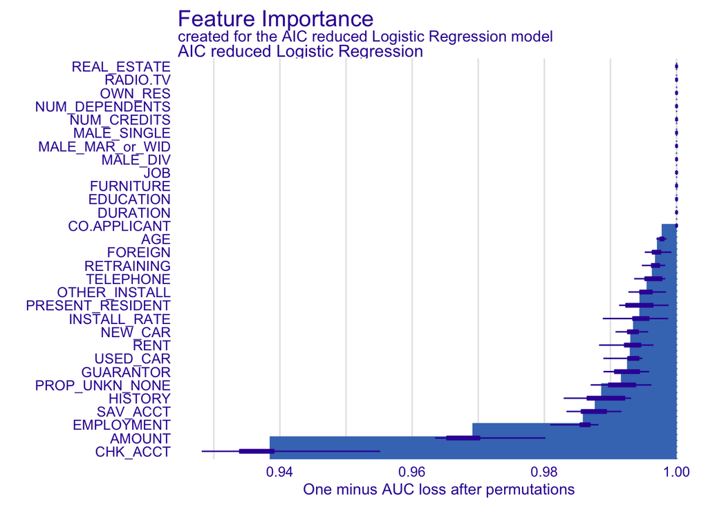

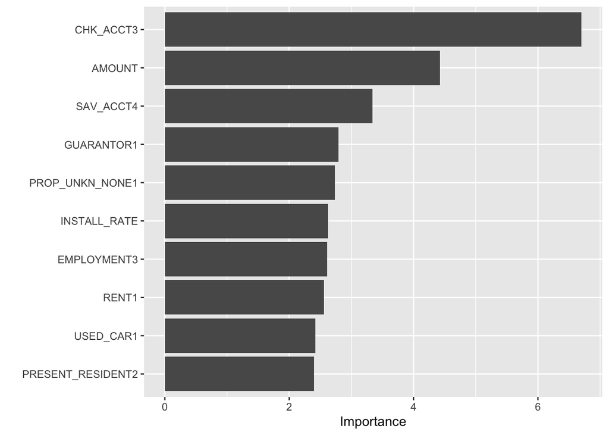

Listed above are the most important variables for the logarithmic regression we reduced. Here again, the CHK_ACCT variable differentiate itself from the others in term of importance in the model prediction.

#### 3.a K-Nearest Neighbor (K=2)

To perform a k-nearest neighbor method, we do not need to balance the data so we will use the unbalanced training set.

We first try to model it using a 2-NN (with Euclidean distance). Note that the model is fitting on the training set and the predictions are computed on the test set.

Confusion Matrix of the 2-Nearest neighbor

|  | Bad credit risk | Good credit risk |
| --- | --- | --- |
| **Bad credit risk** | 21 | 45 |
| **Good credit risk** | 56 | 128 |

```
##          Sensitivity          Specificity       Pos Pred Value
##            0.2727273            0.7398844            0.3181818
##       Neg Pred Value            Precision               Recall
##            0.6956522            0.3181818            0.2727273
##                   F1           Prevalence       Detection Rate
##            0.2937063            0.3080000            0.0840000
## Detection Prevalence    Balanced Accuracy
##            0.2640000            0.5063058
```

The table is read as follow :

- We predicted 21 Bad credits and there were indeed 21 observed Bad credits. But the prediction misjudges 45 good credits by predicting bad credits.
- We predicted 128 Good credits as it was in fact a Good credits but 56 where predicted as Good while it was in fact Bad.

The prediction is not perfect. We need to try to improve the prediction by changing K at that point. Therefore, we use K=3.

#### 3.b K-Nearest Neighbor (K=3)

Confusion Matrix of the 3-Nearest neighbor

[output not shown]

```
##          Sensitivity          Specificity       Pos Pred Value
##            0.1818182            0.8381503            0.3333333
##       Neg Pred Value            Precision               Recall
##            0.6971154            0.3333333            0.1818182
##                   F1           Prevalence       Detection Rate
##            0.2352941            0.3080000            0.0560000
## Detection Prevalence    Balanced Accuracy
##            0.1680000            0.5099842
```

#### 4. Linear Support Vector Machine

The next model is the linear Support Vector Machine.

```
##
## Call:
## svm(formula = RESPONSE ~ ., data = German_Credit.tr.subs, kernel = "linear")
##
##
## Parameters:
##    SVM-Type:  C-classification
##  SVM-Kernel:  linear
##        cost:  1
##
## Number of Support Vectors:  246
```

Confusion Matrix of the Linear support vector machine

|  | Bad credit risk | Good credit risk |
| --- | --- | --- |
| **Bad credit risk** | 50 | 50 |
| **Good credit risk** | 27 | 123 |

```
##          Sensitivity          Specificity       Pos Pred Value
##            0.6493506            0.7109827            0.5000000
##       Neg Pred Value            Precision               Recall
##            0.8200000            0.5000000            0.6493506
##                   F1           Prevalence       Detection Rate
##            0.5649718            0.3080000            0.2000000
## Detection Prevalence    Balanced Accuracy
##            0.4000000            0.6801667
```

##### Tunning the hyperparameters of Linear SVM

We want to select the good hyperparameters for our linear SVM.

```
## Support Vector Machines with Linear Kernel
##
## 446 samples
##  30 predictor
##   2 classes: '0', '1'
##
## No pre-processing
## Resampling: Cross-Validated (10 fold)
## Summary of sample sizes: 402, 400, 402, 401, 402, 402, ...
## Resampling results:
##
##   Accuracy   Kappa
##   0.7264361  0.4530209
##
## Tuning parameter 'C' was held constant at a value of 1
```

We see that we have a good accuracy (0.72).

```
## Support Vector Machines with Linear Kernel
##
## 446 samples
##  30 predictor
##   2 classes: '0', '1'
##
## No pre-processing
## Resampling: Cross-Validated (10 fold)
## Summary of sample sizes: 402, 400, 402, 401, 402, 402, ...
## Resampling results across tuning parameters:
##
##   C      Accuracy   Kappa
##   1e-02  0.7264339  0.4532044
##   1e-01  0.7286056  0.4575791
##   1e+00  0.7264361  0.4530209
##   1e+01  0.7108278  0.4216992
##   1e+02  0.7130501  0.4261940
##   1e+03  0.7197672  0.4397558
##
## Accuracy was used to select the optimal model using the largest value.
## The final value used for the model was C = 0.1.
```

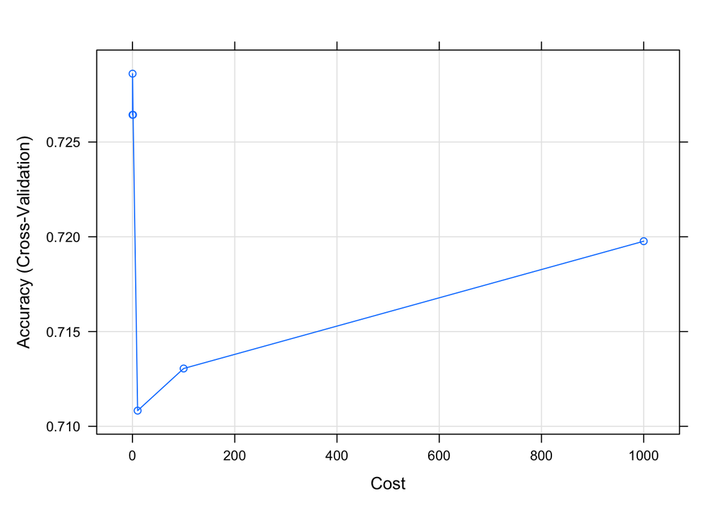

Confusion Matrix of the Tuned linear support vector machine

|  | Bad credit risk | Good credit risk |
| --- | --- | --- |
| **Bad credit risk** | 49 | 49 |
| **Good credit risk** | 28 | 124 |

```
##          Sensitivity          Specificity       Pos Pred Value
##            0.6363636            0.7167630            0.5000000
##       Neg Pred Value            Precision               Recall
##            0.8157895            0.5000000            0.6363636
##                   F1           Prevalence       Detection Rate
##            0.5600000            0.3080000            0.1960000
## Detection Prevalence    Balanced Accuracy
##            0.3920000            0.6765633
```

#### 5. Radial Basis Support Vector Machine

We try now with a radial basis kernel (the default).

```
##
## Call:
## svm(formula = RESPONSE ~ ., data = German_Credit.tr.subs, kernel = "radial")
##
##
## Parameters:
##    SVM-Type:  C-classification
##  SVM-Kernel:  radial
##        cost:  1
##
## Number of Support Vectors:  334
```

Confusion Matrix of the Radial base support vector machine

|  | Bad credit risk | Good credit risk |
| --- | --- | --- |
| **Bad credit risk** | 54 | 52 |
| **Good credit risk** | 23 | 121 |

```
##          Sensitivity          Specificity       Pos Pred Value
##            0.7012987            0.6994220            0.5094340
##       Neg Pred Value            Precision               Recall
##            0.8402778            0.5094340            0.7012987
##                   F1           Prevalence       Detection Rate
##            0.5901639            0.3080000            0.2160000
## Detection Prevalence    Balanced Accuracy
##            0.4240000            0.7003603
```

##### Tunning the hyperparameters of Radial basis SVM

```
## Support Vector Machines with Radial Basis Function Kernel
##
## 446 samples
##  30 predictor
##   2 classes: '0', '1'
##
## No pre-processing
## Resampling: Cross-Validated (10 fold)
## Summary of sample sizes: 402, 400, 402, 401, 402, 402, ...
## Resampling results across tuning parameters:
##
##   sigma  C     Accuracy   Kappa
##   0.01      1  0.7309289  0.4618150
##   0.01     10  0.6971476  0.3942416
##   0.01    100  0.6907708  0.3814209
##   0.01    500  0.6975889  0.3950572
##   0.01   1000  0.6975889  0.3950572
##   0.02      1  0.7309816  0.4620420
##   0.02     10  0.6972925  0.3946754
##   0.02    100  0.7064273  0.4127482
##   0.02    500  0.7064273  0.4127482
##   0.02   1000  0.7064273  0.4127482
##   0.05      1  0.7038647  0.4085756
##   0.05     10  0.6860299  0.3726705
##   0.05    100  0.6860299  0.3726705
##   0.05    500  0.6860299  0.3726705
##   0.05   1000  0.6860299  0.3726705
##   0.10      1  0.6588603  0.3190546
##   0.10     10  0.6611792  0.3234506
##   0.10    100  0.6611792  0.3234506
##   0.10    500  0.6611792  0.3234506
##   0.10   1000  0.6611792  0.3234506
##
## Accuracy was used to select the optimal model using the largest value.
## The final values used for the model were sigma = 0.02 and C = 1.
```

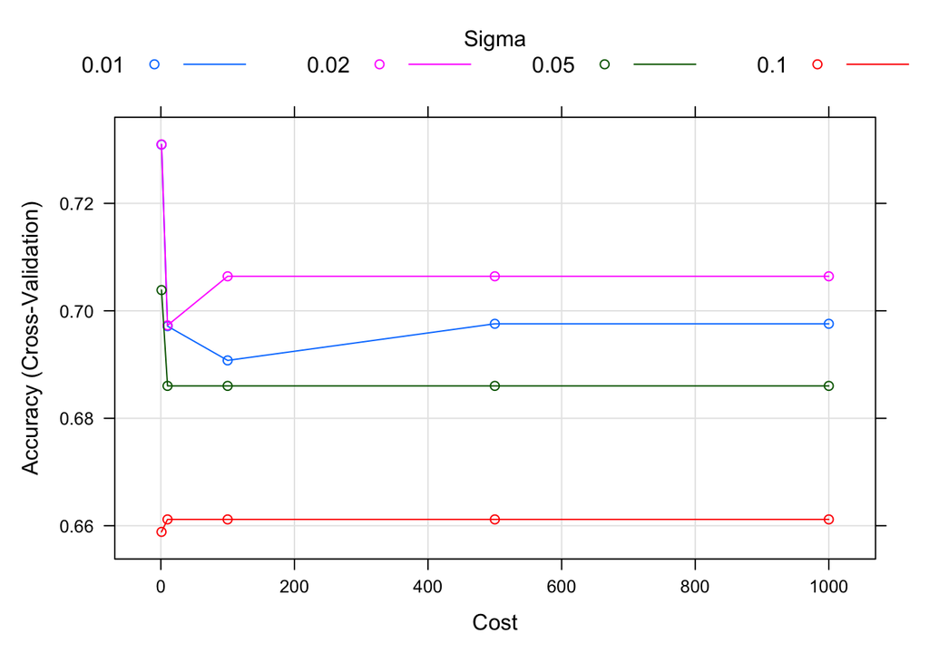

```
##   sigma C
## 6  0.02 1
```

Confusion Matrix of the Tuned radial base support vector machine

|  | Bad credit risk | Good credit risk |
| --- | --- | --- |
| **Bad credit risk** | 54 | 53 |
| **Good credit risk** | 23 | 120 |

```
##          Sensitivity          Specificity       Pos Pred Value
##            0.7012987            0.6936416            0.5046729
##       Neg Pred Value            Precision               Recall
##            0.8391608            0.5046729            0.7012987
##                   F1           Prevalence       Detection Rate
##            0.5869565            0.3080000            0.2160000
## Detection Prevalence    Balanced Accuracy
##            0.4280000            0.6974702
```

#### 6. Neural Network - Simple hyperparameter tuning

To select the good parameters, we build a search grid and fit the model with each possible value in the grid. This is brute force and time consuming. The best model is selected among all the possible choices.

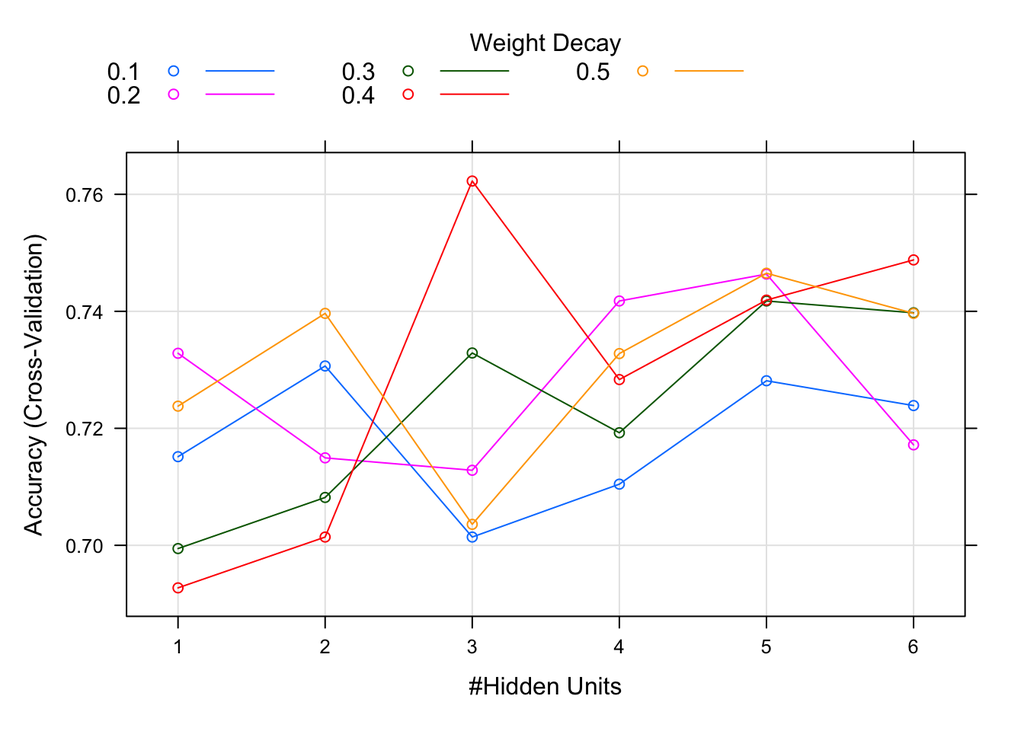

Confusion Matrix of the Hyperparameter tuned neural network 3 nodes

|  | Bad credit risk | Good credit risk |
| --- | --- | --- |
| **Bad credit risk** | 52 | 53 |
| **Good credit risk** | 25 | 120 |

```
##          Sensitivity          Specificity       Pos Pred Value
##            0.6753247            0.6936416            0.4952381
##       Neg Pred Value            Precision               Recall
##            0.8275862            0.4952381            0.6753247
##                   F1           Prevalence       Detection Rate
##            0.5714286            0.3080000            0.2080000
## Detection Prevalence    Balanced Accuracy
##            0.4200000            0.6844831
```

#### 7. Gradient Boosting

The Gradient Boosting model accepts only numerical values so we have some transformation to do on our data in order to use it.

```
## ##### xgb.Booster
## raw: 31.2 Mb
## call:
##   xgb.train(params = xgb_params, data = xgb_train, nrounds = 5000,
##     verbose = 1)
## params (as set within xgb.train):
##   booster = "gbtree", eta = "0.01", max_depth = "8", gamma = "4", subsample = "0.75", colsample_bytree = "1", objective = "multi:softmax", eval_metric = "mlogloss", num_class = "2", validate_parameters = "TRUE"
## xgb.attributes:
##   niter
## callbacks:
##   cb.print.evaluation(period = print_every_n)
## # of features: 46
## niter: 5000
## nfeatures : 46
```

Here we have an accuracy of 68.4%. It is good but there is room for improvement.

Confusion Matrix of the Gadient boosting

|  | Bad credit risk | Good credit risk |
| --- | --- | --- |
| **Bad credit risk** | 57 | 59 |
| **Good credit risk** | 20 | 114 |

```
##          Sensitivity          Specificity       Pos Pred Value
##            0.7402597            0.6589595            0.4913793
##       Neg Pred Value            Precision               Recall
##            0.8507463            0.4913793            0.7402597
##                   F1           Prevalence       Detection Rate
##            0.5906736            0.3080000            0.2280000
## Detection Prevalence    Balanced Accuracy
##            0.4640000            0.6996096
```

## Review of statistics

Once all the models were modelized we compared them according to their scores and metrics. Below we summarized all their accuracy into one table.

Scores of the models (continued below)

|  | Big classification tree | Pruned classification tree | Autoprune classification tree | Logistic regression | AIC reduced Logistic regression | Linear support vector machine |
| --- | --- | --- | --- | --- | --- | --- |
| **Accuracy** | 0.644 | 0.564 | 0.584 | 0.704 | 0.684 | 0.692 |
| **Kappa** | 0.2945 | 0.2083 | 0.2251 | 0.3479 | 0.32 | 0.3328 |
| **Accuracy lower bound** | 0.5812 | 0.5001 | 0.5202 | 0.6432 | 0.6224 | 0.6307 |
| **Accuracy upper bound** | 0.7033 | 0.6264 | 0.6458 | 0.7599 | 0.7411 | 0.7486 |
| **Accuracy null** | 0.692 | 0.692 | 0.692 | 0.692 | 0.692 | 0.692 |
| **Accuracy P-value** | 0.9552 | 1 | 0.9999 | 0.369 | 0.6369 | 0.5308 |
| **Mcnemar P-value** | 1.158e-07 | 1.822e-14 | 3.352e-12 | 0.04813 | 0.00693 | 0.01217 |

|  | Tuned linear support vector machine | Radial base support vector machine | Tuned radial base support vector machine | Hyperparameter tuned neural network 3 nodes | Gradient Boosting |
| --- | --- | --- | --- | --- | --- |
| **Accuracy** | 0.692 | 0.7 | 0.696 | 0.688 | 0.684 |
| **Kappa** | 0.3283 | 0.3628 | 0.3564 | 0.3352 | 0.35 |
| **Accuracy lower bound** | 0.6307 | 0.6391 | 0.6349 | 0.6266 | 0.6224 |
| **Accuracy upper bound** | 0.7486 | 0.7561 | 0.7524 | 0.7449 | 0.7411 |
| **Accuracy null** | 0.692 | 0.692 | 0.692 | 0.692 | 0.692 |
| **Accuracy P-value** | 0.5308 | 0.4219 | 0.4762 | 0.5847 | 0.6369 |
| **Mcnemar P-value** | 0.02265 | 0.001224 | 0.0008794 | 0.002235 | 1.909e-05 |

The accuracy means that out of total number of observations, the model predicted correctly 70% of them. The Cohen’s Kappa Coefficient means that there is 36% of agreement, indicating that the raters agree in their classification for 36% of the cases.

Another table is done to compare the KNN because they were not performed on the balanced dataset.

Scores of the KNN models

|  | 2-Nearest neighbor | 3-Nearest neighbor |
| --- | --- | --- |
| **Accuracy** | 0.596 | 0.636 |
| **Kappa** | 0.01313 | 0.02285 |
| **AccuracyLower** | 0.5323 | 0.573 |
| **AccuracyUpper** | 0.6574 | 0.6957 |
| **AccuracyNull** | 0.692 | 0.692 |
| **AccuracyPValue** | 0.9995 | 0.9752 |
| **McnemarPValue** | 0.3197 | 0.000365 |